# PCA, PCR for Brand Competition

2/4/2022

### Build brand maps for car brands

(The brandmaps are at the end of file, together with recommendations). Here’s the process of Principle Component Regression:

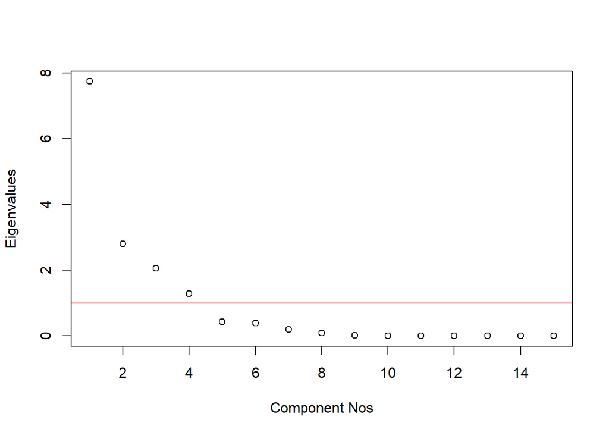

```r
cars <- readxl::read_xlsx("Cars_Data.xlsx", sheet = "Infinity Data")

## Generate Correlation Matrix
cars.y = cars[,17]
cars.x = as.matrix(cars[,2:16])
cars.cormat = cor(cars.x)

## Eigen Decomposition
eigen.mat = eigen(cars.cormat)
eigenval = eigen.mat$values
eigenvec = eigen.mat$vectors
plot(eigenval, ylab = "Eigenvalues", xlab = "Component Nos")
abline(h = 1, col = "red")
```

#### Determine how many factors to retain

By the rule that retain only eigenvalues greater than 1, there are 4 components to retain.

#### Assign names to the retained factors

Now let’s assign names to retained eigenvectors, and flip signs if they generates negative coefficients in PCR:

```r
## Retain eigen vectors > 1
ego <- eigenval[eigenval > 1]
nn <- nrow(as.matrix(ego))
new.eigenvec<- eigenvec[,1:nn]
new.eigenvec <- ifelse(abs(new.eigenvec) < 0.3, 0, new.eigenvec)
## Assign names
rownames(new.eigenvec) <- c("attractive","quiet","unreliable","poorly.built","interesting","sporty","uncomfortable","roomy","easy.service","prestige","common","economical","successful","avantgarde","poor.value")
## Flip signs (R generates different z every time, so the components need flipping may differ)
new.eigenvec[,1] = - new.eigenvec[,1]
new.eigenvec[,2] = - new.eigenvec[,2]
```

### Principle Component Regression

```r
## Principle Component Regression
cars.z <- cars.x %*% new.eigenvec
cars.y <- as.numeric(unlist(cars.y))
pcr <- lm(cars.y ~ cars.z)
summary(pcr)
```

```
##
## Call:
## lm(formula = cars.y ~ cars.z)
##
## Residuals:
##        1        2        3        4        5        6        7        8
## -0.41399  0.20488  0.21196  0.17883 -0.17872  0.29476  0.07001 -0.13008
##        9       10
## -0.11977 -0.11788
##
## Coefficients:
##             Estimate Std. Error t value Pr(>|t|)
## (Intercept)  2.18458    0.43161   5.061 0.003895 **
## cars.z1      0.68944    0.07258   9.499 0.000219 ***
## cars.z2      0.28516    0.11920   2.392 0.062209 .
## cars.z3      0.46138    0.11900   3.877 0.011675 *
## cars.z4      0.21219    0.21267   0.998 0.364205
## ---
## Signif. codes:  0 '***' 0.001 '**' 0.01 '*' 0.05 '.' 0.1 ' ' 1
##
## Residual standard error: 0.303 on 5 degrees of freedom
## Multiple R-squared:  0.9742, Adjusted R-squared:  0.9536
## F-statistic: 47.21 on 4 and 5 DF,  p-value: 0.0003671
```

### Iso Preference Line and Ideal Vector

#### Iso-preference line and its difference from the regression line

In brand competition, Iso Preference line is where every point in that line represent same level of preference to that brand; and every point to the right of it are more preferred, every point to the left of the line is less preferred.  
Regression line, however, denotes different level of preferences, or the dependent variable. As independent variable changes, the points in regression line is different levels of dependent variable. It is more alike an average of where all the points line up.

#### What is an ideal vector and why it indicates the direction of increasing preferences

Ideal vector is a vector perpendicular to iso-preference lines, whose direction points to the way product design should improve – the reason behind is that as Iso Preference lines are parallel to each other, the shortest path from a less-preferred Iso line to a more-preferred Iso line is go from the former perpendicularly to the latter.  
We ignore z4 in the following calculation as it is insignificant.

#### Compute the angles of iso-preference line and ideal vector arrow

See calculation below:

```r
iso_ideal <- function(b1, b2){
  slope.iso.preference = - b1/b2
  slope.ideal.vector = b2/b1

  angle.iso.preference = atan(slope.iso.preference)*180/pi
  angle.ideal.vector = atan(slope.ideal.vector)*180/pi

  obj = c("iso angle"=angle.iso.preference, "ideal angle"=angle.ideal.vector)

  return(obj)
}

b1 = as.vector(coef(pcr)[2])
b2 = as.vector(coef(pcr)[3])
b3 = as.vector(coef(pcr)[4])


iso_ideal(b1, b2)
```

```
##   iso angle ideal angle
##   -67.52971    22.47029
```

```r
iso_ideal(b1, b3)
```

```
##   iso angle ideal angle
##   -56.20927    33.79073
```

```r
iso_ideal(b2, b3)
```

```
##   iso angle ideal angle
##    -31.7183     58.2817
```

### Find 95% confidence interval for the angle of the ideal vector

```r
## bb: boostrap time
bb <- 1000
rsq.out2 <- matrix(0, bb, 1)
nn <- nrow(cars)
iso.res <- matrix(0, bb, 1)
ideal.res <- matrix(0, bb, 1)

## bootstrapping ##
for(ii in 1:bb) {

    data.sample <- cars[sample(nn, nn, replace = T),]       # create (y*, x*) by resampling rows in original data matrix
    y.sample <- data.sample[,17]
    x.sample <- as.matrix(data.sample[,2:16])
    cor.sample <- cor(x.sample)

    ## Eigen Decomposition ##
  eigen.sample = eigen(cor.sample)
  eigenval.sample = eigen.sample$values
  eigenvec.sample = eigen.sample$vectors

  ## Retain eigen vectors > 1 ##
  ego.sample <- eigenval.sample[eigenval.sample > 1]
  nn.sample <- nrow(as.matrix(ego.sample))
  new.eigenvec.sample<- eigenvec.sample[,1:nn.sample]
  new.eigenvec.sample <- ifelse(abs(new.eigenvec.sample) < 0.3, 0, new.eigenvec.sample)
  rownames(new.eigenvec.sample) <- c("attractive","quiet","unreliable","poorly.built","interesting","sporty","uncomfortable","roomy","easy.service","prestige","common","economical","successful","avantgarde","poor.value")


  ## PCR - test to see if need to flip sign ##
  z.test <- x.sample %*% new.eigenvec.sample
  y.test <- as.numeric(unlist(y.sample))
  pcr.test <- lm(y.test ~ z.test)

  # flip sign when coef < 0
  for (j in 2:length(coef(pcr.test))){

    if (is.na(coef(pcr.test)[j])){} # when z[j] == N/A, pass
    else if (coef(pcr.test)[j] < 0){
      new.eigenvec.sample[, j-1] = -new.eigenvec.sample[, j-1]
    }
  }

  ## PCR ##
  z.sample <- x.sample %*% new.eigenvec.sample
  y.sample <- as.numeric(unlist(y.sample))
  pcr.sample <- lm(y.sample ~ z.sample)

  b1.sample = as.vector(coef(pcr.sample)[2])
  b2.sample = as.vector(coef(pcr.sample)[3])

  iso.res[ii] <-iso_ideal(b1.sample, b2.sample)[1]
  ideal.res[ii] <- iso_ideal(b1.sample, b2.sample)[2]
}
```

Calculate confidence interval for ideal vector:

```r
# ISO preference line
iso.CI.lower <- sort(iso.res)[25]
iso.CI.higher <- sort(iso.res)[975]
ideal.CI.lower <- sort(ideal.res)[25]
ideal.CI.higher <- sort(ideal.res)[975]

#c(iso.CI.lower, iso.CI.higher)
c(ideal.CI.lower, ideal.CI.higher)
```

```
## [1]  1.030163 61.823224
```

### Recommend to Infinity’s managers what they should do to improve their product design

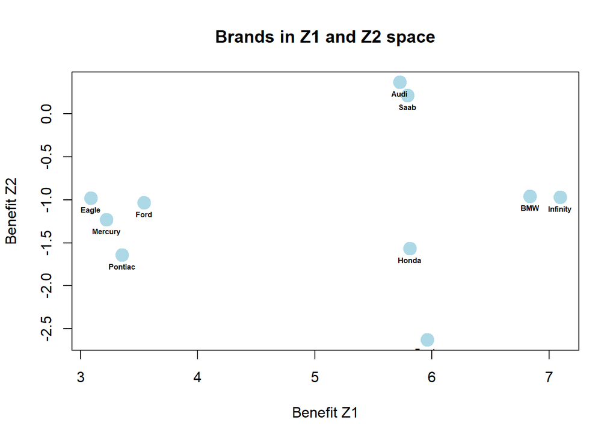

```r
rownames(cars.z) <- c("Infinity","Ford","Audi","Toyota","Eagle","Honda","Saab","Pontiac","BMW","Mercury")
plot(cars.z[,1], cars.z[,2], main = "Brands in Z1 and Z2 space", xlab = "Benefit Z1", ylab = "Benefit Z2", col = "lightblue", pch = 19, cex = 2)
text(cars.z, labels = row.names(cars.z), font = 2, cex = 0.5, pos = 1)
```

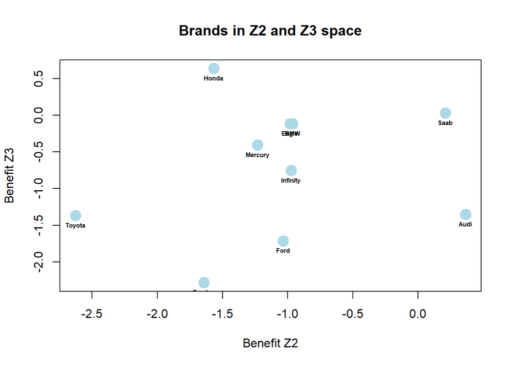

```r
plot(cars.z[,2], cars.z[,3], main = "Brands in Z2 and Z3 space", xlab = "Benefit Z2", ylab = "Benefit Z3", col = "lightblue", pch = 19, cex = 2)
text(cbind(cars.z[,2],cars.z[,3]), labels = row.names(cars.z), font = 2, cex = 0.5, pos = 1)
```

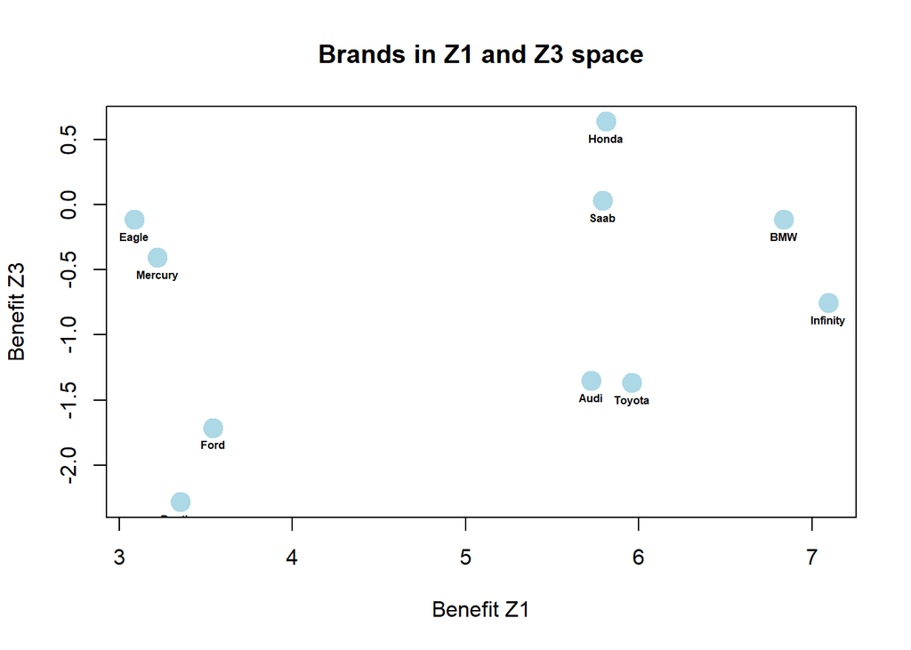

```r
plot(cars.z[,1], cars.z[,3], main = "Brands in Z1 and Z3 space", xlab = "Benefit Z1", ylab = "Benefit Z3", col = "lightblue", pch = 19, cex = 2)
text(cbind(cars.z[,1],cars.z[,3]), labels = row.names(cars.z), font = 2, cex = 0.5, pos = 1)
```

```r
## see what z represents:
new.eigenvec
```

```
##                     [,1]       [,2]       [,3]       [,4]
## attractive     0.3262814  0.0000000  0.0000000  0.0000000
## quiet          0.3173818  0.0000000  0.0000000  0.0000000
## unreliable     0.0000000  0.4011014  0.0000000  0.0000000
## poorly.built  -0.3319244  0.0000000  0.0000000  0.0000000
## interesting    0.0000000  0.0000000 -0.4290683  0.0000000
## sporty         0.0000000 -0.4288285  0.0000000  0.0000000
## uncomfortable  0.0000000  0.0000000  0.0000000  0.0000000
## roomy          0.0000000  0.3789204  0.0000000  0.0000000
## easy.service   0.0000000 -0.4279673  0.0000000  0.0000000
## prestige       0.3322855  0.0000000  0.0000000  0.0000000
## common         0.0000000  0.0000000  0.0000000 -0.4663407
## economical     0.0000000  0.0000000  0.6642165  0.0000000
## successful     0.3155394  0.0000000  0.0000000  0.0000000
## avantgarde     0.0000000  0.0000000  0.0000000  0.6685725
## poor.value     0.0000000  0.0000000 -0.4710589  0.0000000
```